# Cyclistic Data Analysis - Yearly Overview

Gayatri Paul

2023-01-06

## 4. Analyze

#### Statistics

```r
average_ride_length = round(mean(df$ride_length), 2)
print(paste0("Average ride_length = ", average_ride_length))
```

```
## [1] "Average ride_length = 19.41"
```

```r
max_ride_length = round(max(df$ride_length), 2)
print(paste0("Max. ride_length = ", max_ride_length))
```

```
## [1] "Max. ride_length = 41387.25"
```

```r
tb_no_of_days <- df %>%
  group_by(rider_type) %>%
  summarise(min_no_of_days=min(no_of_days),max_no_of_days=max(no_of_days),avg_no_of_days=round(mean(no_of_days),digits=2))
tb_no_of_days
```

```
## # A tibble: 2 × 4
##   rider_type min_no_of_days max_no_of_days avg_no_of_days
##   <chr>               <dbl>          <dbl>          <dbl>
## 1 casual                  1             30           1.01
## 2 member                  1              3           1
```

```r
rides_by_day_of_week <- df %>%
  count(day_of_week)

mode_of_day_of_week <- rides_by_day_of_week %>%
  filter(n == max(n)) %>%
  select(day_of_week)

print(paste0("Mode of the day of week = ", mode_of_day_of_week))
```

```
## [1] "Mode of the day of week = saturday"
```

```r
df_casual <- df %>%
  filter(rider_type == 'casual')

rides_by_day_of_week_casual <- df_casual%>%
  count(day_of_week)

mode_of_day_of_week_casual <- rides_by_day_of_week_casual %>%
  filter(n == max(n)) %>%
  select(day_of_week)

print(paste0("Mode of the day of week for casual rider = ", mode_of_day_of_week_casual))
```

```
## [1] "Mode of the day of week for casual rider = saturday"
```

```r
df_member <- df %>%
  filter(rider_type == 'member')

rides_by_day_of_week_member <- df_member%>%
  count(day_of_week)

mode_of_day_of_week_member <- rides_by_day_of_week_member %>%
  filter(n == max(n)) %>%
  select(day_of_week)

print(paste0("Mode of the day of week for member = ", mode_of_day_of_week_member))
```

```
## [1] "Mode of the day of week for member = wednesday"
```

#### Money spent by casual riders per ride

```r
keep <- c("ride_id", "rideable_type", "rider_type", "ride_length")
df_casual <- df_casual[keep]

df_casual_classic <- df_casual %>%
  filter(rideable_type=="classic_bike" & ride_length>180)
nrow(df_casual_classic)
```

```
## [1] 8595
```

There are significant number of rides which exceeded the time limit.

We do not know whether the casual riders had day pass or single ride pass We don’t know if each ride in day pass has been given new ride ID , lets assume considering minimum extra charges: classic bike if ride length <= 30 - single ride pass + no extra charge if ride length <= 60 single ride pass + extra charge if ride length 60< x < 180 - day pass + no extra charge if ride length > 180 - day pass + extra charges electric bike No time limit as bike is charged per minute docked bike pricing same as classic but without extra charge

As we are making assumptions, the value won’t be exact, but we can get a general idea.

```r
casual_rider_charges <- df_casual %>%
  mutate(ride_length = ceiling(ride_length)) %>%
  mutate(charges=
           ifelse(rideable_type=="electric_bike", 1+0.39*(ride_length),
                  ifelse(rideable_type=="docked_bike", 3.30,
                         ifelse(ride_length <= 30, 3.30,
                                ifelse(ride_length <= 60, 3.30+0.15*(ride_length-30),
                                       ifelse(ride_length <= 180, 15,
                                              15+(ride_length-180)*0.16))))))
```

```r
avg_charge_per_ride_casual_rider = round(sum(casual_rider_charges$charges)/nrow(casual_rider_charges), digits=2)
print(paste0("avg_charge_per_ride_casual_rider = ", avg_charge_per_ride_casual_rider, " $"))
```

```
## [1] "avg_charge_per_ride_casual_rider = 6.38 $"
```

```r
max_charge_per_ride_casual_rider = max(casual_rider_charges$charges)
print(paste0("max_charge_per_ride_casual_rider = ", max_charge_per_ride_casual_rider, " $"))
```

```
## [1] "max_charge_per_ride_casual_rider = 235.8 $"
```

```r
# Casual riders who spent more than annual membership charges

Target <- casual_rider_charges %>%
  filter(charges > 108) %>%
  nrow()

Target
```

```
## [1] 4105
```

At least 4105 Casual riders paid more than Annual membership for a single ride. These people will be easy to convert into members. More data will be needed for further analysis.

```r
# Casual riders who spent more than annual membership charges

Target1 <- casual_rider_charges %>%
  filter(charges > 100) %>%
  nrow()

Target1
```

```
## [1] 4296
```

## Members vs Casual Riders at a glance

#### Number of rides

```r
riders_count <- df %>%
  group_by(rider_type) %>%
  summarize(count = n())

total_rides <- nrow(df)

riders_count$percentage <- round((riders_count$count/ total_rides)*100, digits = 2)
```

```r
riders_count_freq_tbl <- riders_count%>%
  bind_rows(summarise(., across(where(is.numeric), sum),
                      across(where(is.character), ~'Total')))
```

```r
percentage <- round(riders_count$percentage, digits=2)
rider_type <- riders_count$rider_type

ypos = cumsum(percentage) - 0.5 * percentage
ypos = 100 - ypos

pie1 = ggplot() + theme_bw() +
  geom_bar(aes(x = "", y = percentage, fill = rider_type),
           stat = "identity", color = "white") +
  coord_polar("y", start = 0) +
  ggtitle("Riders Count") +
  theme(plot.title = element_text(hjust = 0.5, size = 20),
        axis.title = element_blank(),
        axis.text = element_blank(),
        axis.ticks = element_blank(),
        panel.grid=element_blank(),
        panel.border = element_blank()) +
  theme(legend.text=element_text(size=12),
        legend.title = element_text(hjust = 0.5, size=15),
        legend.key.size = unit(1,"cm")) +
  geom_text(aes(x = "", y = ypos, label = paste0(percentage, "%")), size = 4)
```

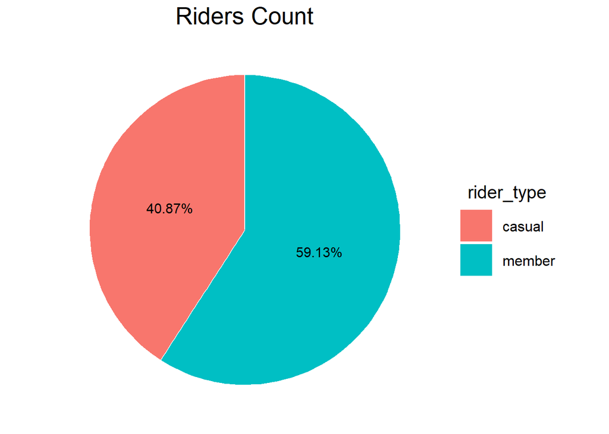

```r
pie1
```

```r
riders_count_freq_tbl
```

```
## # A tibble: 3 × 3
##   rider_type   count percentage
##   <chr>        <int>      <dbl>
## 1 casual     2609952       40.9
## 2 member     3776332       59.1
## 3 Total      6386284      100
```

- Bike usage was observed to be more in Annual members compared to casual riders.

#### Average ride duration

```r
avg_ride_length <- df %>%
  group_by(rider_type) %>%
  summarise(avg_ride_length = round(mean(ride_length), digits=2))
```

```r
bar1 <- ggplot(data=avg_ride_length, aes(x=rider_type, y=avg_ride_length)) +
  geom_bar(stat="identity", width = 0.5, fill="purple")+
  ggtitle("Average ride duration by rider type")+
  theme(plot.title = element_text(hjust = 0.5, size = 12))
```

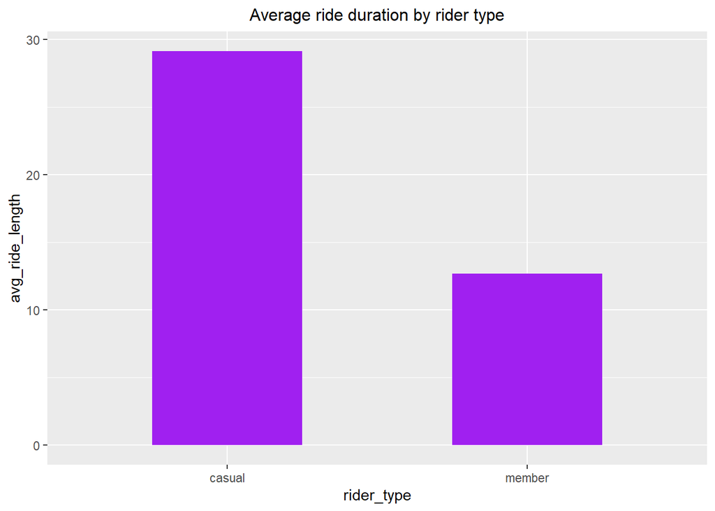

```r
bar1
```

```r
avg_ride_length
```

```
## # A tibble: 2 × 2
##   rider_type avg_ride_length
##   <chr>                <dbl>
## 1 casual                29.1
## 2 member                12.7
```

- Average ride duration for members was 12.69 mins.
- Average ride duration were higher in Casual riders (29.13 mins).

  This may indicate that :
- Members used bikes for their daily commute to work or University &
- Casual riders used the bikes for longer distances or leisure activities.

## Trends based on day of the week

#### Number of rides

```r
no_of_rides_by_day <- df %>%
  group_by(day_of_week, rider_type) %>%
  summarise(no_of_rides = n())
```

```r
no_of_rides_by_day_tbl <- spread(no_of_rides_by_day, key= "rider_type", value= "no_of_rides")
```

```r
positions <- c("sunday","monday","tuesday","wednesday","thursday","friday","saturday")

bar2 <- ggplot(data=no_of_rides_by_day, aes(x=day_of_week, y=no_of_rides, fill=rider_type)) +
  geom_bar(stat="identity", width = 0.5, position = 'dodge')+
  scale_x_discrete(limits = positions)+
  ggtitle("Number of rides by day of the week & rider type")+
  theme(plot.title = element_text(hjust = 0.5, size = 12))
```

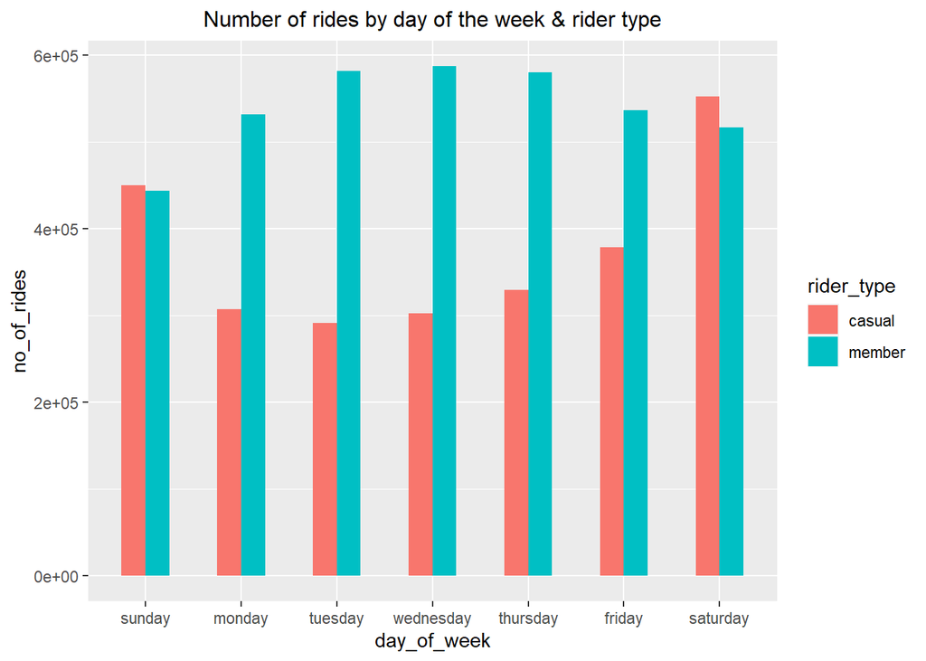

```r
bar2
```

```r
no_of_rides_by_day_tbl
```

```
## # A tibble: 7 × 3
## # Groups:   day_of_week [7]
##   day_of_week casual member
##   <chr>        <int>  <int>
## 1 friday      378440 536453
## 2 monday      306995 531311
## 3 saturday    551952 516322
## 4 sunday      449653 443931
## 5 thursday    329245 579743
## 6 tuesday     291437 581226
## 7 wednesday   302230 587346
```

- Number of rides for annual members were seen to be higher on weekdays. This helps us reaffirm our theory that members use the bikes for short distance daily commutes to and from work or University.
- Number of rides were highest on Saturdays and Sundays for casual riders which again confirms our previous assumption that the casual riders used bikes for leisure activities like exploring the city, going to movies, cafes or restaurants.
- Number of rides by casual riders were marginally higher than members on Saturdays and Sundays. On all other days, number of rides by members significantly higher than casual riders. This is also an indication that the significant proportion of casual riders may be tourists.

#### Average ride duration

```r
avg_ride_length1 <- df %>%
  group_by(day_of_week) %>%
  summarise(avg_ride_length = round(mean(ride_length), digits=2))
```

```r
positions <- c("sunday","monday","tuesday","wednesday","thursday","friday","saturday")
bar3 <- ggplot(data=avg_ride_length1, aes(x=day_of_week, y=avg_ride_length)) +
  geom_bar(stat="identity", width = 0.5, fill="orange")+
  scale_x_discrete(limits = positions)+
  ggtitle("Average ride duration by day of the week")+
  theme(plot.title = element_text(hjust = 0.5, size = 12))
```

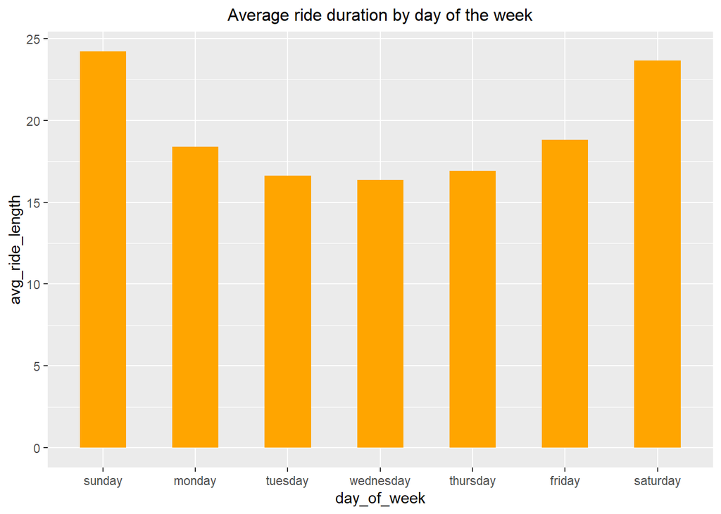

```r
bar3
```

```r
avg_ride_length1
```

```
## # A tibble: 7 × 2
##   day_of_week avg_ride_length
##   <chr>                 <dbl>
## 1 friday                 18.8
## 2 monday                 18.4
## 3 saturday               23.6
## 4 sunday                 24.2
## 5 thursday               16.9
## 6 tuesday                16.6
## 7 wednesday              16.4
```

- Average ride duration was highest on Sundays followed by Saturdays.
- The ride lengths remained in the similar range from Tuesdays to Thursdays but were slightly higher on Mondays and Fridays. This may be due to the long Weekends.

### Average ride duration by day of the week & rider type

```r
avg_ride_length_by_day <- df %>%
  group_by(day_of_week, rider_type) %>%
  summarise(avg_ride_length = round(mean(ride_length), digits=2))
```

```r
library(tidyr)

avg_ride_length_by_day_tbl <- spread(avg_ride_length_by_day, key= "rider_type", value= "avg_ride_length")

avg_ride_length_by_day_tbl <- avg_ride_length_by_day_tbl %>%
  rename( "avg_ride_length_casual" = "casual",
          "avg_ride_length_member" = "member")
```

```r
bar4 <- ggplot(data=avg_ride_length_by_day, aes(x=day_of_week, y=avg_ride_length, fill=rider_type)) +
  geom_bar(stat="identity", width = 0.5, position = 'dodge')+
  scale_x_discrete(limits = positions)+
  ggtitle("Average ride duration by day of the week and rider type")+
  theme(plot.title = element_text(hjust = 0.5, size = 12))
```

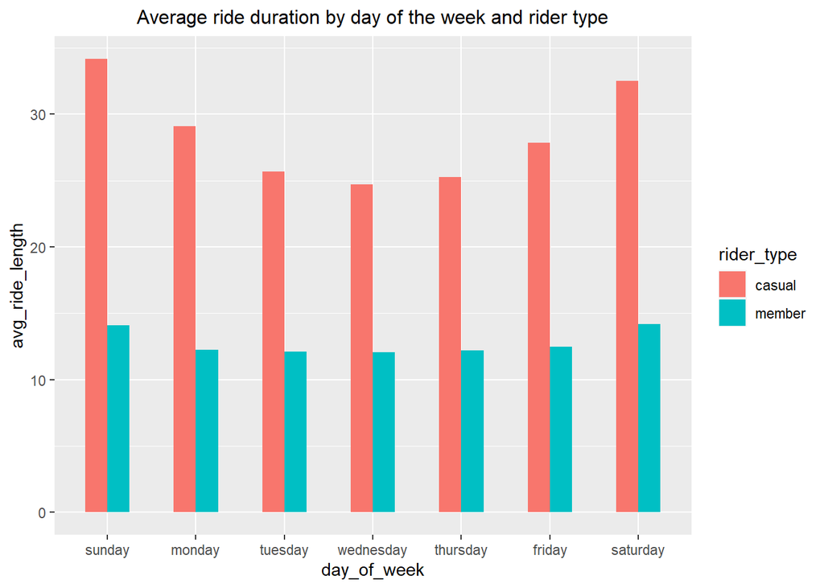

```r
bar4
```

```r
avg_ride_length_by_day_tbl
```

```
## # A tibble: 7 × 3
## # Groups:   day_of_week [7]
##   day_of_week avg_ride_length_casual avg_ride_length_member
##   <chr>                        <dbl>                  <dbl>
## 1 friday                        27.8                   12.5
## 2 monday                        29.1                   12.2
## 3 saturday                      32.5                   14.2
## 4 sunday                        34.2                   14.1
## 5 thursday                      25.3                   12.2
## 6 tuesday                       25.7                   12.1
## 7 wednesday                     24.7                   12.0
```

- Average ride duration for casual riders (25 mins or more) was consistently higher than annual members (less than 15 mins) regardless of the day of the week.
- It was seen to be higher on weekend compared to weekdays in Casual riders as well as members.

## Bike-type wise trend

#### Number of rides by rider type

```r
bike_type <- df %>%
  group_by(rideable_type, rider_type) %>%
  summarise(no_of_rides = n())
```

```r
bike_type_tbl <- spread(bike_type, key= "rider_type", value= "no_of_rides")
```

```r
bar5 <- ggplot(data=bike_type, aes(x=rideable_type, y=no_of_rides, fill=rider_type)) +
  geom_bar(stat="identity", width = 0.5, position = 'dodge')+
  ggtitle("Number of rides by rideable type & rider type")+
  theme(plot.title = element_text(hjust = 0.5, size = 12))
```

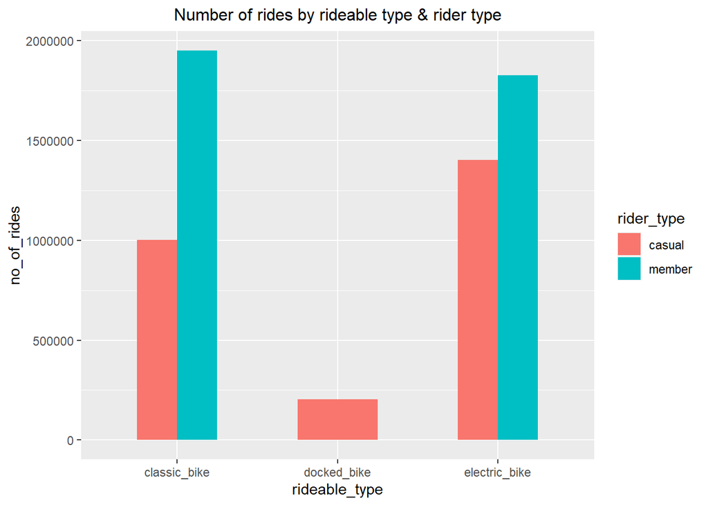

```r
bar5
```

```r
bike_type_tbl
```

```
## # A tibble: 3 × 3
## # Groups:   rideable_type [3]
##   rideable_type  casual  member
##   <chr>           <int>   <int>
## 1 classic_bike  1002953 1950970
## 2 docked_bike    205078      NA
## 3 electric_bike 1401921 1825362
```

- Classic bike was the bike of preference for members, closely followed by electric bike. Members did not use docked bike even once throughout the year.
- Casual riders preferred electric bikes over classic bikes. Casual riders did opt for docked bikes occasionally.

#### Number of rides by day of the week

```r
bike_type2 <- df %>%
  group_by(day_of_week,rideable_type) %>%
  summarise(no_of_rides = n())
```

```r
bike_type2_tbl <- spread(bike_type2, key= "rideable_type", value= "no_of_rides")
```

```r
bar6 <- ggplot(data=bike_type2, aes(x=day_of_week, y=no_of_rides, fill=rideable_type)) +
  geom_bar(stat="identity", width = 0.5, position = 'dodge')+
  scale_x_discrete(limits = positions)+
  ggtitle("Number of rides by rideable type & day of the week")+
  theme(plot.title = element_text(hjust = 0.5, size = 12))
```

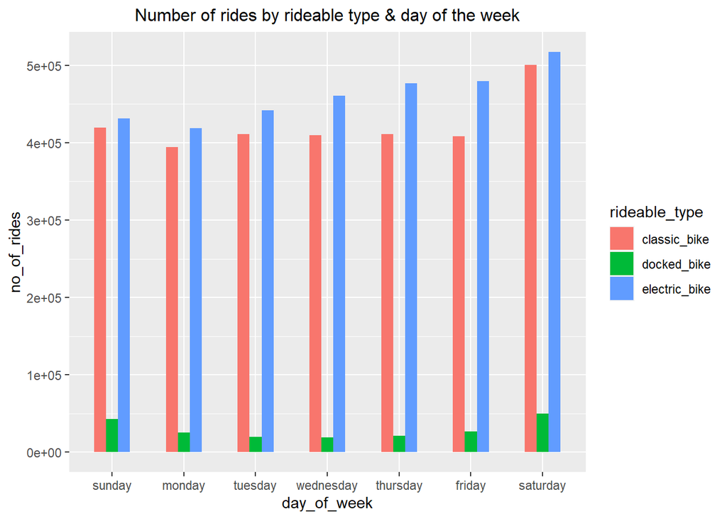

```r
bar6
```

```r
bike_type2_tbl
```

```
## # A tibble: 7 × 4
## # Groups:   day_of_week [7]
##   day_of_week classic_bike docked_bike electric_bike
##   <chr>              <int>       <int>         <int>
## 1 friday            408071       27120        479702
## 2 monday            394140       25235        418931
## 3 saturday          500859       49902        517513
## 4 sunday            419319       42886        431379
## 5 thursday          410990       20938        477060
## 6 tuesday           410890       19720        442053
## 7 wednesday         409654       19277        460645
```

This must have resulted in

- more people choosing electric bikes.
- Faster rides means faster bike returns and in turn more availability.

#### Average ride duration by rideable type & rider type

```r
avg_ride_length_by_ride_type <- df %>%
  group_by(rideable_type, rider_type) %>%
  summarise(avg_ride_length = round(mean(ride_length), digits=2))
```

```r
avg_ride_length_by_ride_type_tbl <- spread(avg_ride_length_by_ride_type, key= "rider_type", value= "avg_ride_length")

avg_ride_length_by_ride_type_tbl <- avg_ride_length_by_ride_type_tbl %>%
  rename( "avg_ride_length_casual" = "casual",
          "avg_ride_length_member" = "member")
```

```r
bar7 <- ggplot(data=avg_ride_length_by_ride_type, aes(x=rideable_type, y=avg_ride_length, fill=rider_type)) +
  geom_bar(stat="identity", width = 0.5, position = 'dodge')+
  ggtitle("Average ride duration by rideable type & rider type")+
  theme(plot.title = element_text(hjust = 0.5, size = 12))
```

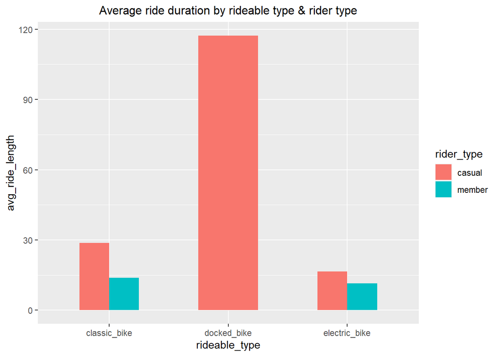

```r
bar7
```

```r
avg_ride_length_by_ride_type_tbl
```

```
## # A tibble: 3 × 3
## # Groups:   rideable_type [3]
##   rideable_type avg_ride_length_casual avg_ride_length_member
##   <chr>                          <dbl>                  <dbl>
## 1 classic_bike                    28.8                   13.8
## 2 docked_bike                    117.                    NA
## 3 electric_bike                   16.5                   11.5
```

- This graph shows that rides were faster on electric bikes compared to classic / docked bikes.

## Month-wise Trends

#### Number of rides by month-year

```r
monthwise_trend <- df %>%
  group_by(month_year) %>%
  summarise(no_of_rides = n())
```

```r
positions3 <- c("10 2021","11 2021","12 2021","1 2022","2 2022","3 2022", "4 2022", "5 2022", "6 2022", "7 2022", "8 2022", "9 2022", "10 2022")

bar8 <- ggplot(data=monthwise_trend, aes(x=month_year, y=no_of_rides)) +
  geom_bar(stat="identity", width = 0.5, fill="orange")+
  scale_x_discrete(limits = positions3)+
  ggtitle("Number of rides by month-year")+
  theme(plot.title = element_text(hjust = 0.5, size = 12))
```

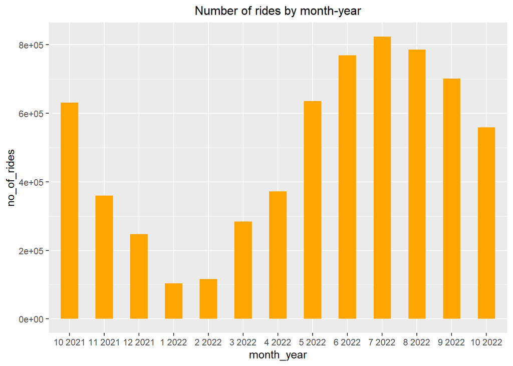

```r
bar8
```

```r
monthwise_trend
```

```
## # A tibble: 13 × 2
##    month_year no_of_rides
##    <chr>            <int>
##  1 1 2022          103765
##  2 10 2021         631156
##  3 10 2022         558620
##  4 11 2021         359892
##  5 12 2021         247519
##  6 2 2022          115604
##  7 3 2022          284024
##  8 4 2022          371218
##  9 5 2022          634810
## 10 6 2022          769138
## 11 7 2022          823416
## 12 8 2022          785855
## 13 9 2022          701267
```

- This graph shows how the number of rides gradually increased around summer and decreased during winters.

#### Number of rides by month-year & rider type

```r
monthwise_trend1 <- df %>%
  group_by(month_year,rider_type) %>%
  summarise(no_of_rides = n())
```

```r
monthwise_trend_tbl1 <- spread(monthwise_trend1, key= "rider_type", value= "no_of_rides")
```

```r
positions3 <- c("10 2021","11 2021","12 2021","1 2022","2 2022","3 2022", "4 2022", "5 2022", "6 2022", "7 2022", "8 2022", "9 2022", "10 2022")

bar9 <- ggplot(data=monthwise_trend1, aes(x=month_year, y=no_of_rides, fill=rider_type)) +
  geom_bar(stat="identity", width = 0.7, position = 'dodge')+
  scale_x_discrete(limits = positions3)+
  ggtitle("Number of rides by month-year & rider type")+
  theme(plot.title = element_text(hjust = 0.5, size = 12),
        axis.text.x = element_text(angle = 90, vjust = 0.5, hjust=1))
```

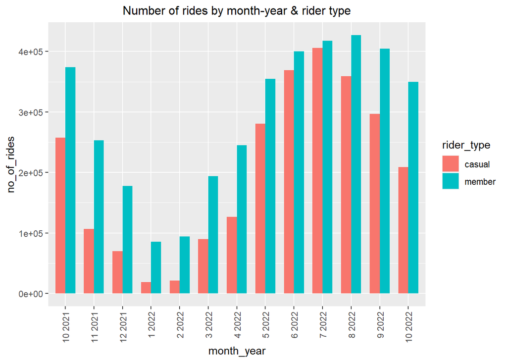

```r
bar9
```

```r
monthwise_trend_tbl1
```

```
## # A tibble: 13 × 3
## # Groups:   month_year [13]
##    month_year casual member
##    <chr>       <int>  <int>
##  1 1 2022      18517  85248
##  2 10 2021    257203 373953
##  3 10 2022    208961 349659
##  4 11 2021    106884 253008
##  5 12 2021     69729 177790
##  6 2 2022      21414  94190
##  7 3 2022      89874 194150
##  8 4 2022     126398 244820
##  9 5 2022     280387 354423
## 10 6 2022     369022 400116
## 11 7 2022     406013 417403
## 12 8 2022     358886 426969
## 13 9 2022     296664 404603
```

- Number of rides by members were always higher than casual riders.
- There was marginal difference between number of rides by casual riders and members June and July.
- The difference kept increasing as the winter approached, and during winter even rides by members decreased.

## Season-wise Trends

#### Number of rides

```r
season <- df %>%
  group_by(season) %>%
  summarise(no_of_rides = n())

season$percentage <- round((season$no_of_rides/ total_rides)*100, digits=2)
```

```r
seasonal_freq_tbl <- season%>%
  bind_rows(summarise(., across(where(is.numeric), sum),
                      across(where(is.character), ~'Total')))
```

```r
percentage2 <- round(season$percentage, digits=2)
seasons <- season$season

ypos1 = cumsum(percentage2) - 0.5 * percentage2
ypos1 = 100 - ypos1

pie2 <- ggplot() + theme_bw() +
  geom_bar(aes(x = "", y = percentage2, fill = seasons),
           stat = "identity", color = "white") +
  coord_polar("y", start = 0) +
  ggtitle("Seasonwise Trend") +
  theme(plot.title = element_text(hjust = 0.5, size = 20),
        axis.title = element_blank(),
        axis.text = element_blank(),
        axis.ticks = element_blank(),
        panel.grid=element_blank(),
        panel.border = element_blank()) +
  theme(legend.text=element_text(size=12),
        legend.title = element_text(hjust = 0.5, size=15),
        legend.key.size = unit(1,"cm")) +
  geom_text(aes(x = "", y = ypos1, label = paste0(percentage2, "%")), size = 4)
```

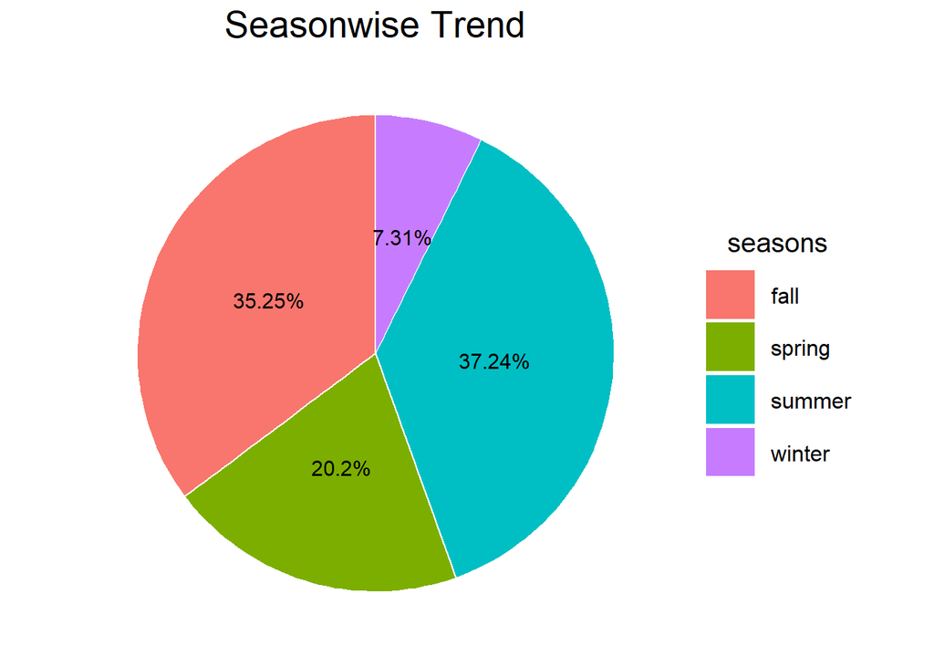

```r
pie2
```

```r
seasonal_freq_tbl
```

```
## # A tibble: 5 × 3
##   season no_of_rides percentage
##   <chr>        <int>      <dbl>
## 1 fall       2250935      35.2
## 2 spring     1290052      20.2
## 3 summer     2378409      37.2
## 4 winter      466888       7.31
## 5 Total      6386284     100
```

- Highest numbers of rides were observed in Summer followed by fall.
- Lowest number of rides were seen in Winters.
- As the data is for Chicago, which has tremendous amounts of snow and winds during winters, such low numbers of rides during winters are justified.

#### Number of rides by Season & Rider type

```r
seasonwise_rides <- df %>%
  group_by(season,rider_type) %>%
  summarise(no_of_rides = n())
```

```r
seasonwise_rides_tbl <- spread(seasonwise_rides, key= "rider_type", value= "no_of_rides")
```

```r
positions2 <- c("winter","spring","summer","fall")

bar10 <- ggplot(data=seasonwise_rides, aes(x=season, y=no_of_rides, fill=rider_type)) +
  geom_bar(stat="identity", width = 0.5, position = 'dodge')+
  scale_x_discrete(limits = positions2)+
  ggtitle("Number of rides by Season & Rider type")+
  theme(plot.title = element_text(hjust = 0.5, size = 12))
```

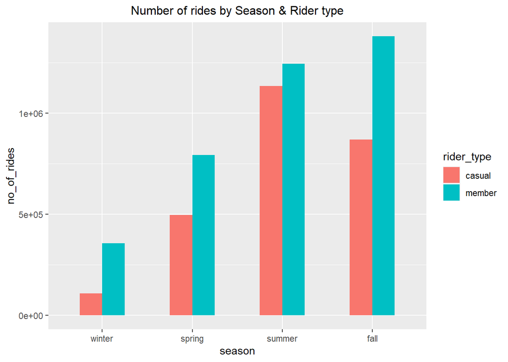

```r
bar10
```

```r
seasonwise_rides_tbl
```

```
## # A tibble: 4 × 3
## # Groups:   season [4]
##   season  casual  member
##   <chr>    <int>   <int>
## 1 fall    869712 1381223
## 2 spring  496659  793393
## 3 summer 1133921 1244488
## 4 winter  109660  357228
```

- Number of rides by members were higher than Casual riders each season.
- Fall was season in which members used maximum number of bike rides.
- Maximum number of rides by casual riders were seen in Summer.

#### Average ride duration by Season & Rider type

```r
avg_ride_length_by_season <- df %>%
  group_by(season, rider_type) %>%
  summarise(avg_ride_length = round(mean(ride_length), digits=2))
```

```r
avg_ride_length_by_season_tbl <- spread(avg_ride_length_by_season, key= "rider_type", value= "avg_ride_length")

avg_ride_length_by_season_tbl <- avg_ride_length_by_season_tbl %>%
  rename( "avg_ride_length_casual" = "casual",
          "avg_ride_length_member" = "member")
```

```r
positions2 <- c("winter","spring","summer","fall")

bar11 <- ggplot(data=avg_ride_length_by_season, aes(x=season, y=avg_ride_length, fill=rider_type)) +
  geom_bar(stat="identity", width = 0.5, position = 'dodge')+
  scale_x_discrete(limits = positions2)+
  ggtitle("Average ride duration by season & rider type")+
  theme(plot.title = element_text(hjust = 0.5, size = 12))
```

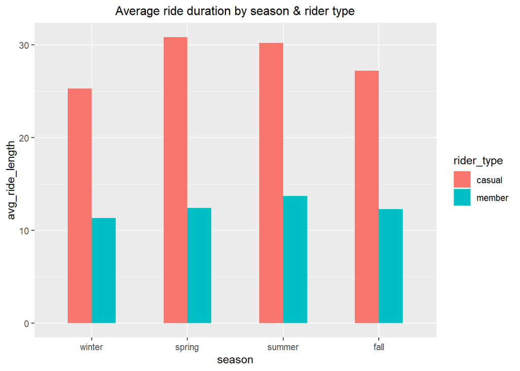

```r
bar11
```

```r
avg_ride_length_by_season_tbl
```

```
## # A tibble: 4 × 3
## # Groups:   season [4]
##   season avg_ride_length_casual avg_ride_length_member
##   <chr>                   <dbl>                  <dbl>
## 1 fall                     27.2                   12.3
## 2 spring                   30.8                   12.4
## 3 summer                   30.2                   13.7
## 4 winter                   25.3                   11.3
```

- Average ride length remained within the range of 25 to 31 mins.
- Average ride duration remained within the range of 11 to 14 mins.

## Holiday-wise Trends

```r
#find unique dates in data and create a new data frame

unique_dates <- unique(df$start_date)
unique_dates_df <- as.data.frame(unique_dates)
```

```r
#add day column to new data frame

unique_dates_df$day_num <- wday(unique_dates_df$unique_dates)

unique_dates_df <- unique_dates_df %>%
  mutate(day=
           ifelse(day_num==1,"sunday",
                  ifelse(day_num==2, "monday",
                         ifelse(day_num==3, "tuesday",
                                ifelse(day_num==4, "wednesday",
                                       ifelse(day_num==5, "thursday",
                                              ifelse(day_num==6, "friday",
                                                     "saturday" )))))))
```

```r
#add holiday column to new data frame

unique_dates_df <- unique_dates_df %>%
  mutate(holidays=
           ifelse(unique_dates=="2021-11-11" |unique_dates=="2021-11-25"|unique_dates=="2021-12-24"
                  |unique_dates=="2021-12-31"|unique_dates=="2022-01-01"|unique_dates=="2022-03-17"
                  |unique_dates=="2022-05-30"|unique_dates=="2022-07-04"|unique_dates=="2022-09-05"
                  |day=="sunday"|day=="saturday",
                  "holiday",
                  "workday"))
```

```r
holiday_tbl <- unique_dates_df %>%
  group_by(holidays) %>%
  summarise("no_of_days"=n())

holiday_tbl
```

```
## # A tibble: 2 × 2
##   holidays no_of_days
##   <chr>         <int>
## 1 holiday         122
## 2 workday         274
```

```r
no_of_rides_by_holiday <- df %>%
  group_by(holiday,rider_type) %>%
  summarise("no_of_rides"= n())

no_of_rides_by_holiday <- no_of_rides_by_holiday %>%
  spread(key = rider_type, value=no_of_rides)

no_of_rides_by_holiday$total = no_of_rides_by_holiday$casual + no_of_rides_by_holiday$member

no_of_rides_by_holiday$num_of_days <- holiday_tbl$no_of_days

no_of_rides_by_holiday <- as.data.frame(no_of_rides_by_holiday)

no_of_rides_by_holiday
```

```
##   holiday  casual  member   total num_of_days
## 1 holiday 1060024 1019811 2079835         122
## 2 workday 1549928 2756521 4306449         274
```

```r
rides_by_holiday <- no_of_rides_by_holiday %>%
  select(holiday,casual,member,num_of_days)

rides_by_holiday <-rides_by_holiday %>%
  gather(key=rider_type, no_of_rides, casual:member)

rides_by_holiday <- rides_by_holiday %>%
  mutate(avg_no_of_rides = round(no_of_rides/num_of_days,digits=2))
```

```r
total_rides_by_holiday <- no_of_rides_by_holiday %>%
  select(holiday,total,num_of_days) %>%
  rename("no_of_rides" = "total") %>%
  mutate(avg_rides = no_of_rides/num_of_days)
```

```r
all_riders_tbl <- no_of_rides_by_holiday %>%
  select(holiday, total, num_of_days) %>%
  mutate(avg_rides= total/num_of_days)
```

#### Holidays vs Workdays

```r
total_num_of_days = sum(total_rides_by_holiday$num_of_days)

holidays <- total_rides_by_holiday %>%
  mutate(percentage = round(num_of_days/total_num_of_days*100, digits=2)) %>%
  select(holiday, num_of_days, percentage)
```

```r
percentage3 <- round(holidays$percentage, digits=2)

holiday_Class <- holidays$holiday
holiday_Class
```

```
## [1] "holiday" "workday"
```

```r
ypos = cumsum(percentage3) - 0.5 * percentage3
ypos = 100 - ypos


pie3 = ggplot() + theme_bw() +
  geom_bar(aes(x = "", y = percentage3, fill = holiday_Class),
           stat = "identity", color = "white") +
  coord_polar("y", start = 0) +
  ggtitle("Holidays vs Workdays") +
  theme(plot.title = element_text(hjust = 0.5, size = 20),
        axis.title = element_blank(),
        axis.text = element_blank(),
        axis.ticks = element_blank(),
        panel.grid=element_blank(),
        panel.border = element_blank()) +
  theme(legend.text=element_text(size=12),
        legend.title = element_text(hjust = 0.5, size=15),
        legend.key.size = unit(1,"cm")) +
  geom_text(aes(x = "", y = ypos, label = paste0(percentage3, "%")), size = 4)
```

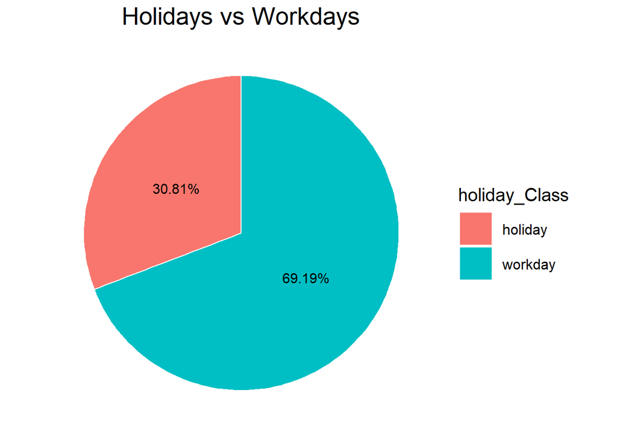

```r
pie3
```

```r
rides_by_holiday
```

```
##   holiday num_of_days rider_type no_of_rides avg_no_of_rides
## 1 holiday         122     casual     1060024         8688.72
## 2 workday         274     casual     1549928         5656.67
## 3 holiday         122     member     1019811         8359.11
## 4 workday         274     member     2756521        10060.30
```

#### Average number of rides

```r
positions5 <- c("holiday", "workday")

bar12 <- ggplot(data=rides_by_holiday, aes(x=holiday, y=avg_no_of_rides, fill=rider_type)) +
  geom_bar(stat="identity", width = 0.5, position = "dodge")+
  ggtitle("Average number of rides by casual riders")+
  scale_x_discrete(limits = positions5)+
  theme(plot.title = element_text(hjust = 0.5, size = 12))
```

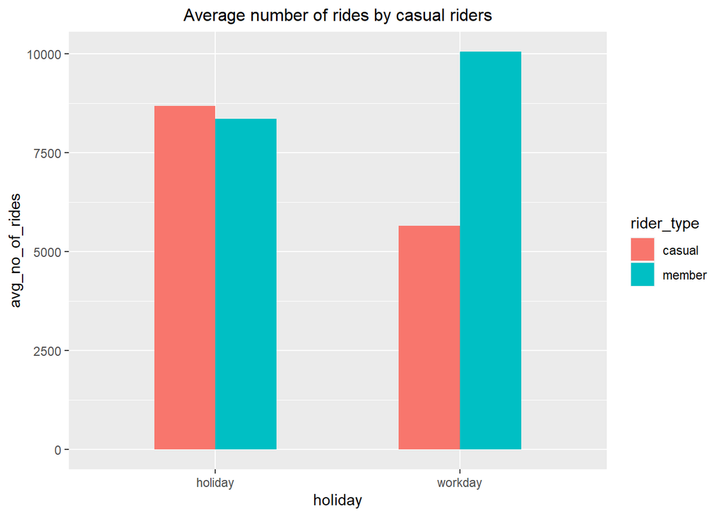

```r
bar12
```

```r
rides_by_holiday
```

```
##   holiday num_of_days rider_type no_of_rides avg_no_of_rides
## 1 holiday         122     casual     1060024         8688.72
## 2 workday         274     casual     1549928         5656.67
## 3 holiday         122     member     1019811         8359.11
## 4 workday         274     member     2756521        10060.30
```

Casual riders used more numbers of bikes during holidays, members preferred to use more bikes on Workdays. During holidays, number of casual riders was more than members. During non-holiday days, number of members was more than casual riders.

```r
bar13 <- ggplot(data=all_riders_tbl, aes(x=holiday, y=avg_rides)) +
  geom_bar(stat="identity", width = 0.5, fill="cyan")+
  ggtitle("Average number of rides")+
  scale_x_discrete(limits = positions5)+
  theme(plot.title = element_text(hjust = 0.5, size = 12))
```

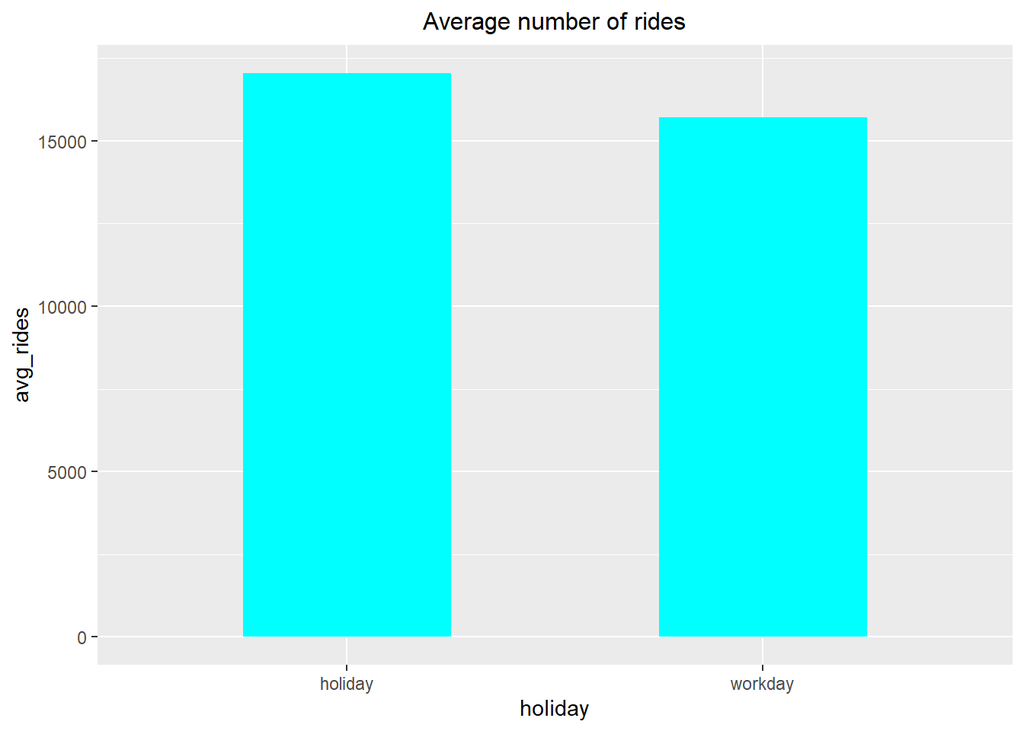

```r
bar13
```

```r
all_riders_tbl
```

```
##   holiday   total num_of_days avg_rides
## 1 holiday 2079835         122  17047.83
## 2 workday 4306449         274  15716.97
```

In general average number of bikes used on holidays was more than workdays.

#### Average ride duration

```r
avg_ride_length_by_holiday_tbl <- df %>%
  group_by(holiday, rider_type) %>%
  summarise(avg_ride_length = round(mean(ride_length),digits=2))

avg_ride_length_by_holiday_tbl
```

```
## # A tibble: 4 × 3
## # Groups:   holiday [2]
##   holiday rider_type avg_ride_length
##   <chr>   <chr>                <dbl>
## 1 holiday casual                33.3
## 2 holiday member                14.1
## 3 workday casual                26.3
## 4 workday member                12.2
```

```r
bar14 <- ggplot(data=avg_ride_length_by_holiday_tbl, aes(x=holiday, y=avg_ride_length, fill=rider_type)) +
  geom_bar(stat="identity", width = 0.5, position = "dodge")+
  ggtitle("Average ride duration by holiday vs nonholiday")+
  scale_x_discrete(limits = positions5)+
  theme(plot.title = element_text(hjust = 0.5, size = 12))
```

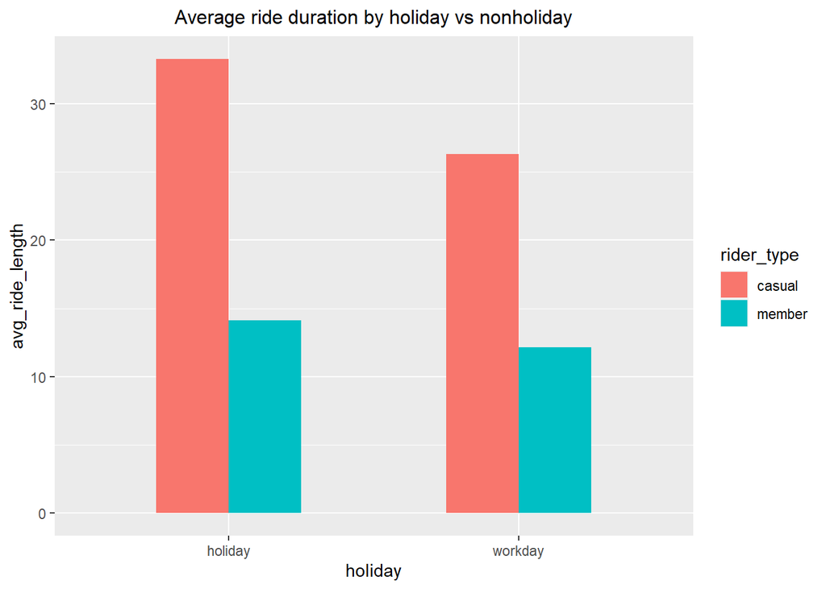

```r
bar14
```

```r
avg_ride_length_by_holiday_tbl
```

```
## # A tibble: 4 × 3
## # Groups:   holiday [2]
##   holiday rider_type avg_ride_length
##   <chr>   <chr>                <dbl>
## 1 holiday casual                33.3
## 2 holiday member                14.1
## 3 workday casual                26.3
## 4 workday member                12.2
```

Rides duration were seen to be more on holidays compared to work days.